# Child Birthweight Data Representations

Kobbe Harwell

Data Acquisition

```r
site <- "http://www.stat.berkeley.edu/users/statlabs/data/babies.data"
BABIES <- read.table(file=url(site), header=TRUE)
summary(BABIES)
```

```
##       bwt          gestation         parity            age
##  Min.   : 55.0   Min.   :148.0   Min.   :0.0000   Min.   :15.00
##  1st Qu.:108.8   1st Qu.:272.0   1st Qu.:0.0000   1st Qu.:23.00
##  Median :120.0   Median :280.0   Median :0.0000   Median :26.00
##  Mean   :119.6   Mean   :286.9   Mean   :0.2549   Mean   :27.37
##  3rd Qu.:131.0   3rd Qu.:288.0   3rd Qu.:1.0000   3rd Qu.:31.00
##  Max.   :176.0   Max.   :999.0   Max.   :1.0000   Max.   :99.00
##      height          weight        smoke
##  Min.   :53.00   Min.   : 87   Min.   :0.0000
##  1st Qu.:62.00   1st Qu.:115   1st Qu.:0.0000
##  Median :64.00   Median :126   Median :0.0000
##  Mean   :64.67   Mean   :154   Mean   :0.4644
##  3rd Qu.:66.00   3rd Qu.:140   3rd Qu.:1.0000
##  Max.   :99.00   Max.   :999   Max.   :9.0000
```

```r
dim(BABIES)[2]
```

```
## [1] 7
```

Removing subjects if any observations on the subject are “unknown”. The variables `bwt`, `gestation`, `parity`, `age`, `height`, `weight`, and `smoke` use values of 999, 999, 9, 99, 99, 999, and 9, respectively, to denote ‘’unknown.’’

```r
BABIES <- BABIES %>% mutate(bwt = ifelse(bwt == 999, NA, bwt))
BABIES <- BABIES %>% mutate(gestation = ifelse(gestation == 999, NA, gestation))
BABIES <- BABIES %>% mutate(parity = ifelse(parity == 9, NA, parity))
BABIES <- BABIES %>% mutate(age = ifelse(age == 99, NA, age))
BABIES <- BABIES %>% mutate(height = ifelse(height == 99, NA, height))
BABIES <- BABIES %>% mutate(weight = ifelse(weight == 999, NA, weight))
BABIES <- BABIES %>% mutate(smoke = ifelse(smoke == 9, NA, smoke))
```

Cleaning Data Set

```r
CLEAN <- na.omit(BABIES)
dim(CLEAN)
```

```
## [1] 1174    7
```

```r
colNAs<- colSums(is.na(BABIES))
colNAs
```

```
##       bwt gestation    parity       age    height    weight     smoke
##         0        13         0         2        22        36        10
```

```r
colNAs <- as.vector(colSums(is.na(BABIES)))

rowNAs <- table(rowSums(is.na(BABIES)))
rowNAs
```

```
##
##    0    1    2    3
## 1174   43   17    2
```

```r
rowNAs <- as.vector(table(rowSums(is.na(BABIES))))
```

> **Comment:**

```
            The missing values are as follows:
            gestation: 13
            age: 2
            height: 22
            weight: 36
            smoke: 10
            1174 rows have no missing values, 43 rows have 1, 17 rows have 2, and 2 rows have 3 missing values.
```

Sorting the values in `CLEAN` by `bwt`, `gestation`, and `age`. Storing the sorted values in a data frame named `byBGA`.

```r
byBGA <- CLEAN %>% arrange(bwt, gestation, age)
head(byBGA, 6)
```

```
##   bwt gestation parity age height weight smoke
## 1  55       204      0  35     65    140     0
## 2  58       245      0  34     64    156     1
## 3  62       228      0  24     61    107     0
## 4  63       236      1  24     58     99     0
## 5  65       232      0  24     66    125     1
## 6  65       237      0  31     67    130     0
```

```r
tail(byBGA, 6)
```

```
##      bwt gestation parity age height weight smoke
## 1169 170       303      1  21     64    129     0
## 1170 173       293      0  30     63    110     0
## 1171 174       281      0  37     67    155     0
## 1172 174       284      0  39     65    163     0
## 1173 174       288      0  25     61    182     0
## 1174 176       293      1  19     68    180     0
```

Creating a new variable for bodyweight by grams.

```r
  CLEAN <- CLEAN %>% mutate(bwt_gr = bwt*28.35)
```

```r
set.seed(41)

remove <-sample(1:dim(CLEAN)[1],50)
print("Observation to remove:")
```

```
## [1] "Observation to remove:"
```

```r
remove
```

```
##  [1]  163 1029 1120  326  790  114  994  443  630 1069 1109 1170  941  708   97
## [16]   52  466  623   30  276  374  930  676  976  987  156  817  328  461 1149
## [31]  500  860  661  445  738 1162 1166  513  132   27  433 1124 1080  618 1158
## [46] 1033   54   55  492  103
```

```r
CLEAN <- slice(CLEAN,-remove)
dim(CLEAN)[1]
```

```
## [1] 1124
```

```r
head(CLEAN)
```

```
##   bwt gestation parity age height weight smoke  bwt_gr
## 1 120       284      0  27     62    100     0 3402.00
## 2 113       282      0  33     64    135     0 3203.55
## 3 128       279      0  28     64    115     1 3628.80
## 4 108       282      0  23     67    125     1 3061.80
## 5 136       286      0  25     62     93     0 3855.60
## 6 138       244      0  33     62    178     0 3912.30
```

```r
write.csv(CLEAN, file="CLEAN.csv", row.names=FALSE)
```

Finding the percentage of the women in `CLEAN` that are pregnant with their first child and do not smoke. Also those pregnant not for a first time and smoking.

```r
dim(filter(CLEAN, parity==0 & smoke ==0))[1]
```

```
## [1] 509
```

```r
dim(filter(CLEAN, parity==0 & smoke ==0))[1]/dim(CLEAN)[1]*100
```

```
## [1] 45.2847
```

```r
dim(filter(CLEAN, parity==1 & smoke ==1))[1]
```

```
## [1] 112
```

```r
dim(filter(CLEAN, parity==1 & smoke ==1))[1]/dim(CLEAN)[1]*100
```

```
## [1] 9.964413
```

```r
head(CLEAN)
```

```
##   bwt gestation parity age height weight smoke  bwt_gr
## 1 120       284      0  27     62    100     0 3402.00
## 2 113       282      0  33     64    135     0 3203.55
## 3 128       279      0  28     64    115     1 3628.80
## 4 108       282      0  23     67    125     1 3061.80
## 5 136       286      0  25     62     93     0 3855.60
## 6 138       244      0  33     62    178     0 3912.30
```

> **Results:**

```
                    # of women are pregnant with their first child and do not smoke.
                    ~45.3%
                    # of women not pregnant for first time and smoke:
                    ~10%
```

Creating a frequency histogram of the birth weights of babies whose mothers have never smoked and another histogram for the birth weights of babies whose mothers currently smoke.

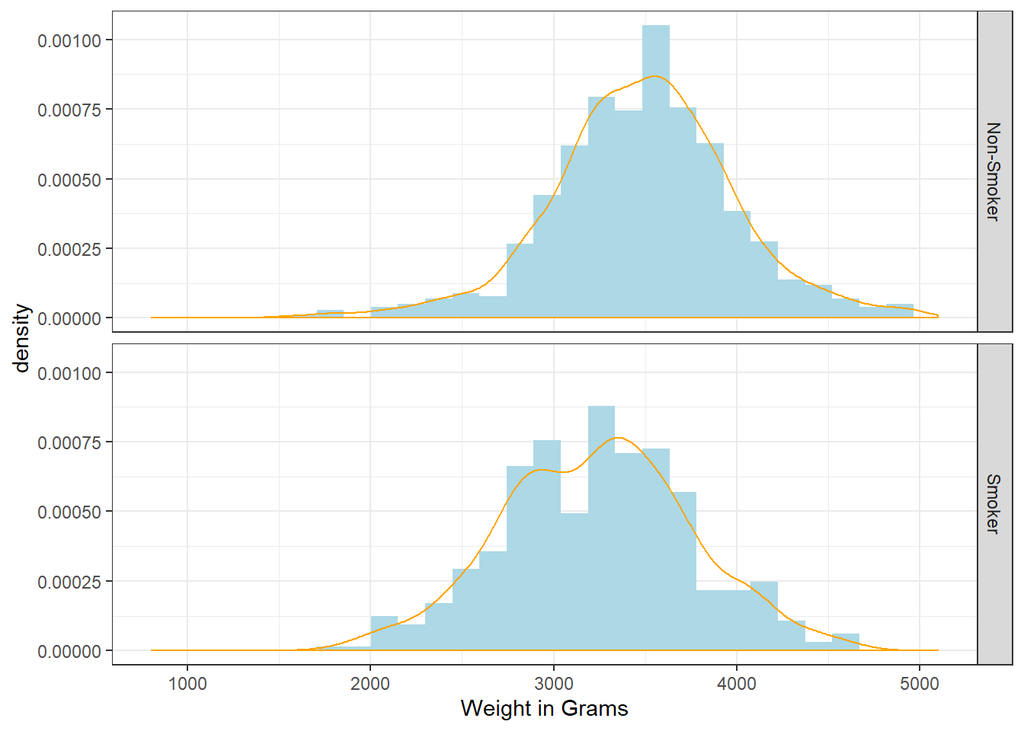

```r
CLEAN <- CLEAN %>% mutate(smoke = factor(smoke, levels = 0:1, labels =c("Non-Smoker", "Smoker")))

   ggplot(data = CLEAN, aes(x =bwt_gr, y= ..density..)) +
   geom_histogram(fill = "lightblue") +
   geom_density(color = "orange") +
   facet_grid(smoke~.) +
   xlim(800, 5100) +
   xlab("Weight in Grams")+
   theme_bw()
```

Exploring Distribution

```r
# Using summarise() and group_by() from dplyr
  CLEAN %>% group_by(smoke) %>% summarize(mean(bwt_gr))
```

```
## # A tibble: 2 x 2
##   smoke      `mean(bwt_gr)`
##   <fct>               <dbl>
## 1 Non-Smoker          3486.
## 2 Smoker              3237.
```

```r
  CLEAN %>% group_by(smoke) %>% summarize(sd(bwt_gr))
```

```
## # A tibble: 2 x 2
##   smoke      `sd(bwt_gr)`
##   <fct>             <dbl>
## 1 Non-Smoker         499.
## 2 Smoker             516.
```

```r
  CLEAN %>% group_by(smoke) %>% summarize(var(bwt_gr))
```

```
## # A tibble: 2 x 2
##   smoke      `var(bwt_gr)`
##   <fct>              <dbl>
## 1 Non-Smoker       248615.
## 2 Smoker           265997.
```

```r
  diff(range(CLEAN$bwt_gr))
```

```
## [1] 3430.35
```

Creating side-by-side boxplots to compare the birth weights (bwt_gr) of babies whose mother’s never smoked and those who currently smoke.

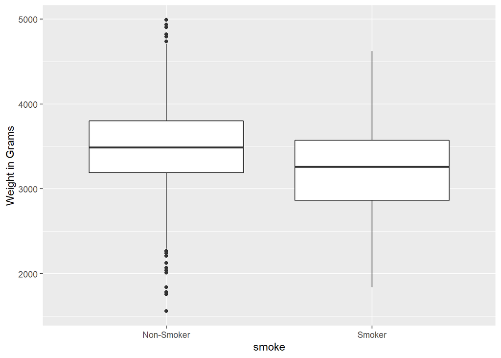

```r
  ggplot(data=CLEAN, aes(x=smoke, y=bwt_gr)) +
  geom_boxplot()+
  ylab("Weight in Grams")
```

Finding the the median weight difference between babies who are firstborn and those who are not (`parity = 1`)?

```r
   CLEAN %>% group_by(parity) %>% summarize(median(bwt_gr))
```

```
## # A tibble: 2 x 2
##   parity `median(bwt_gr)`
##    <int>            <dbl>
## 1      0            3430.
## 2      1            3331.
```

> **Results:** The median weight difference between babies who are firstborn and those who are not is 99 grams.

Creating a graph of the densities for pre-pregnancy `weight` for mothers who have never smoked and for mothers who currently smoke.

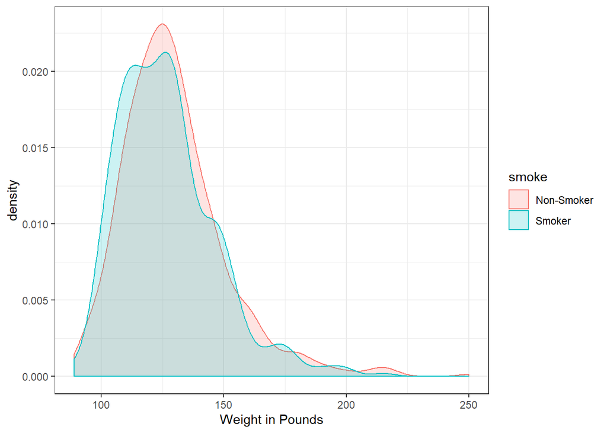

```r
    ggplot(data = CLEAN, aes(x =weight, color=smoke)) +
   geom_density(aes(fill = smoke), alpha=0.2) +
   xlab("Weight in Pounds")+
   theme_bw()
```

Computing the body mass index (`BMI`) for each mother in `CLEAN`. `BMI` is defined as $\text{kg}/\text{m}^2$.

```r
    CLEANP <- CLEAN %>% mutate(weightKg = weight*0.45359, heightM = height*0.0254, BMI = weightKg/(heightM^2))
    head(CLEANP)
```

```
##   bwt gestation parity age height weight      smoke  bwt_gr weightKg heightM
## 1 120       284      0  27     62    100 Non-Smoker 3402.00 45.35900  1.5748
## 2 113       282      0  33     64    135 Non-Smoker 3203.55 61.23465  1.6256
## 3 128       279      0  28     64    115     Smoker 3628.80 52.16285  1.6256
## 4 108       282      0  23     67    125     Smoker 3061.80 56.69875  1.7018
## 5 136       286      0  25     62     93 Non-Smoker 3855.60 42.18387  1.5748
## 6 138       244      0  33     62    178 Non-Smoker 3912.30 80.73902  1.5748
##        BMI
## 1 18.28996
## 2 23.17234
## 3 19.73940
## 4 19.57746
## 5 17.00966
## 6 32.55612
```

Characterizing the distribution of BMI.

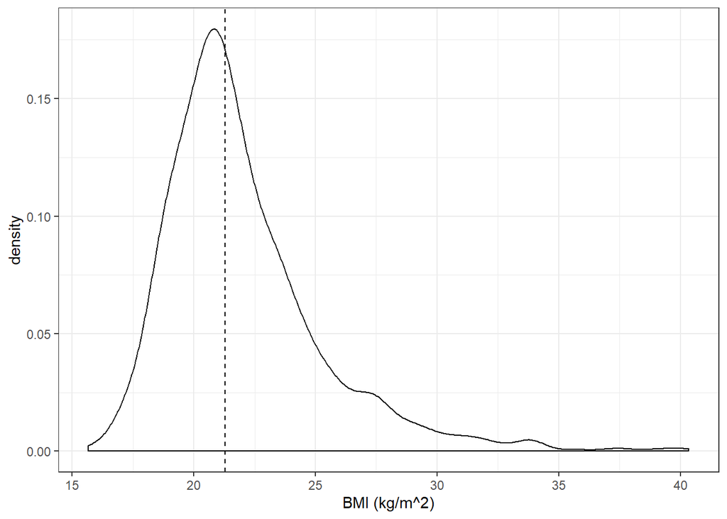

```r
   ggplot(data = CLEANP, aes(x =BMI)) +
   geom_density() +
    geom_vline(data=CLEANP, aes(xintercept = median(BMI)), linetype="dashed")+
   xlab("BMI (kg/m^2)")+
   theme_bw()
```

**Results:**

The BMI distribution skews right and has a single local maximum.

Grouping pregnant mothers according to their BMI quartile.

```r
  cleanQuart <- CLEANP %>% mutate(BMIQuart = ntile(BMI, 4))
  head(cleanQuart %>% arrange(BMIQuart))
```

```
##   bwt gestation parity age height weight      smoke bwt_gr weightKg heightM
## 1 120       284      0  27     62    100 Non-Smoker 3402.0 45.35900  1.5748
## 2 128       279      0  28     64    115     Smoker 3628.8 52.16285  1.6256
## 3 108       282      0  23     67    125     Smoker 3061.8 56.69875  1.7018
## 4 136       286      0  25     62     93 Non-Smoker 3855.6 42.18387  1.5748
## 5 140       351      0  27     68    120 Non-Smoker 3969.0 54.43080  1.7272
## 6 110       281      0  36     61     99     Smoker 3118.5 44.90541  1.5494
##        BMI BMIQuart
## 1 18.28996        1
## 2 19.73940        1
## 3 19.57746        1
## 4 17.00966        1
## 5 18.24566        1
## 6 18.70560        1
```

```r
    notSmoke <- cleanQuart %>% filter(smoke=="Non-Smoker")
    notSmoke %>% group_by(BMIQuart) %>% summarize(mean(bwt_gr))
```

```
## # A tibble: 4 x 2
##   BMIQuart `mean(bwt_gr)`
##      <int>          <dbl>
## 1        1          3458.
## 2        2          3480.
## 3        3          3466.
## 4        4          3535.
```

```r
    notSmoke %>% group_by(BMIQuart) %>% summarize(sd(bwt_gr))
```

```
## # A tibble: 4 x 2
##   BMIQuart `sd(bwt_gr)`
##      <int>        <dbl>
## 1        1         426.
## 2        2         527.
## 3        3         474.
## 4        4         548.
```

```r
    notSmoke %>% group_by(BMIQuart) %>% summarize(median(bwt_gr))
```

```
## # A tibble: 4 x 2
##   BMIQuart `median(bwt_gr)`
##      <int>            <dbl>
## 1        1            3430.
## 2        2            3530.
## 3        3            3445.
## 4        4            3544.
```

```r
    notSmoke %>% group_by(BMIQuart) %>% summarize(IQR(bwt_gr))
```

```
## # A tibble: 4 x 2
##   BMIQuart `IQR(bwt_gr)`
##      <int>         <dbl>
## 1        1          581.
## 2        2          617.
## 3        3          546.
## 4        4          652.
```

```r
    didSmoke <- cleanQuart %>% filter(smoke=="Smoker")
    didSmoke %>% group_by(BMIQuart) %>% summarize(mean(bwt_gr))
```

```
## # A tibble: 4 x 2
##   BMIQuart `mean(bwt_gr)`
##      <int>          <dbl>
## 1        1          3128.
## 2        2          3273.
## 3        3          3351.
## 4        4          3224.
```

```r
    didSmoke %>% group_by(BMIQuart) %>% summarize(sd(bwt_gr))
```

```
## # A tibble: 4 x 2
##   BMIQuart `sd(bwt_gr)`
##      <int>        <dbl>
## 1        1         530.
## 2        2         488.
## 3        3         503.
## 4        4         517.
```

```r
    didSmoke %>% group_by(BMIQuart) %>% summarize(median(bwt_gr))
```

```
## # A tibble: 4 x 2
##   BMIQuart `median(bwt_gr)`
##      <int>            <dbl>
## 1        1            3062.
## 2        2            3289.
## 3        3            3374.
## 4        4            3260.
```

```r
    didSmoke %>% group_by(BMIQuart) %>% summarize(IQR(bwt_gr))
```

```
## # A tibble: 4 x 2
##   BMIQuart `IQR(bwt_gr)`
##      <int>         <dbl>
## 1        1          723.
## 2        2          652.
## 3        3          652.
## 4        4          624.
```

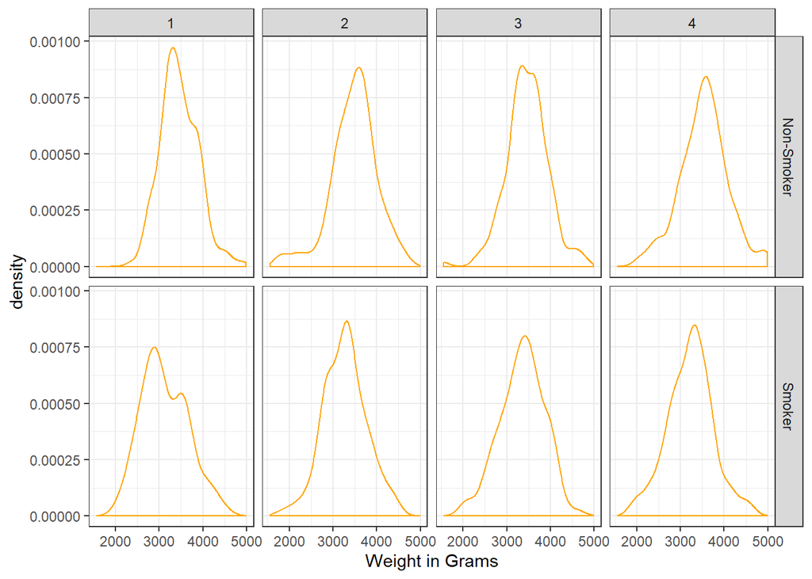

```r
    CLEANP <- CLEANP %>% mutate(BMIQuart = ntile(BMI, 4))

  ggplot(data = CLEANP, aes(x =bwt_gr)) +
   geom_density(color = "orange") +
   facet_grid(smoke~BMIQuart) +
    xlab("Weight in Grams")+
   theme_bw()
```

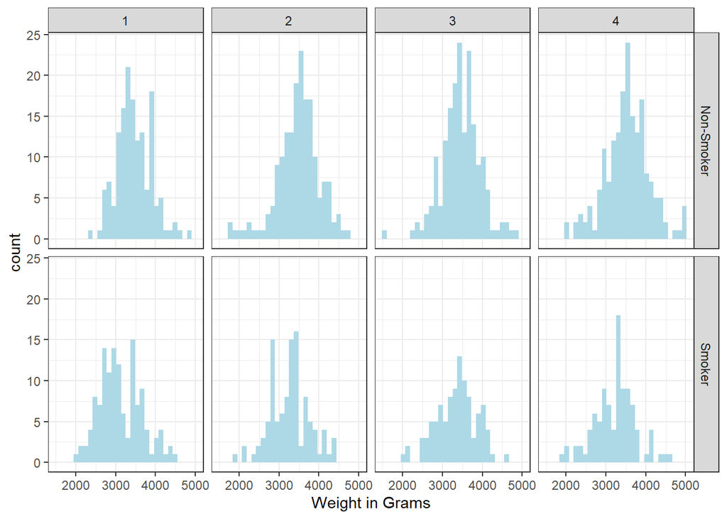

```r
  ggplot(data = CLEANP, aes(x =bwt_gr)) +
   geom_histogram(fill = "lightblue") +
   facet_grid(smoke~BMIQuart) +
    xlab("Weight in Grams")+
   theme_bw()
```

> **Results: Birth weights in each group appear to be relatively symmetric.**

Creating boxplots of `bwt_gr` based on whether the mother smokes conditioned on `BMI` quartiles in order to determine Which one appears to be bigger factor, smoking or BMI?

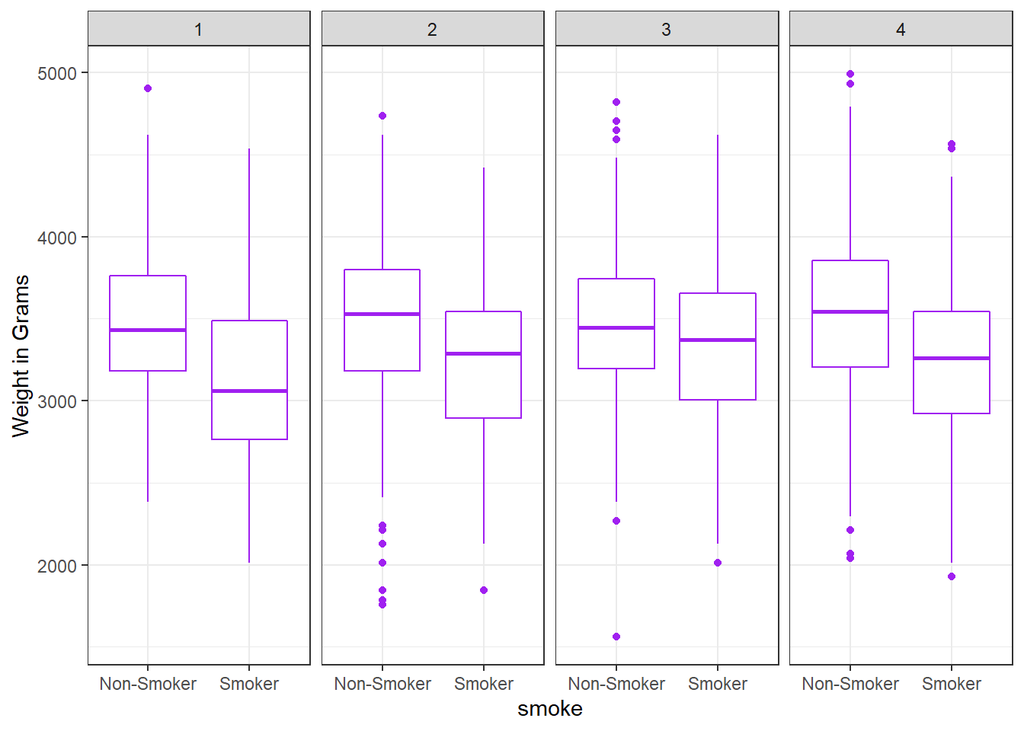

```r
  ggplot(data = CLEANP, aes(x=smoke, y= bwt_gr)) +
   geom_boxplot(color = "purple") +
   facet_grid(.~BMIQuart) +
    ylab("Weight in Grams")+
   theme_bw()
```

> **Results: Smoking appears to be a bigger factor on birth weight than BMI.**

```
## [1] "Fri Apr 24 20:34:47 2020"
```

[output not shown]